# title: “4120 Project”

# author: “Raymond Santiago”

# date: “2026-05-03”

# output: pdf_document

# —

## I. Background

National health and nutrition demographics help explore the factors influencing overall health.  
Understanding the leading factors in Health and Nutrition is consequential for identifying the underlying health trends within the sample. This comes from the National Health and Nutrition Examination Survey. This can yield actionable insights to inform specialized community efforts to address concerns within communities at greatest risk.

## II. Research Problem

- What demographic, clinical, and lifestyle factors are significantly associated with the waist-to-height ratio in U.S. adults during the study period?
- Among the risk factors, which ones best predict the waist-to-height ratio, for modifiable and non-modifiable risk factors?

**Modifiable behaviors:**

- What behavior and lifestyle choices are associated with a higher WHR?

**Non-Modifiable behaviors:**

- Which race and sex predictors are most significant, and which communities should be flagged for intervention?

### Model 1: Stepwise

```
## Start:  AIC=-30976.87
## whr ~ (ID + age + sex + race_eth + educ_lev + income + smk_status +
##     drk_pdy + hvy.drk + phy.act + BMI + waist + hypertension +
##     bp.di.m + bp.sy.m + diabetes + diab_famhist + prediabetes +
##     birth.risk + triglcd + GGT + ALT + CAP + slptm.wd + slphr.wd +
##     slptm.wn + slphr.wn + log_bmi) - ID
##
##                Df Sum of Sq    RSS    AIC
## - slptm.wn     51   0.03520 3.5462 -31035
## - slptm.wd     50   0.04426 3.5552 -31022
## - birth.risk    1   0.00003 3.5110 -30979
## - drk_pdy       1   0.00007 3.5111 -30979
## - hypertension  1   0.00031 3.5113 -30978
## - GGT           1   0.00074 3.5117 -30978
## - diab_famhist  1   0.00074 3.5117 -30978
## - slphr.wd      1   0.00094 3.5119 -30978
## - CAP           1   0.00103 3.5120 -30978
## - prediabetes   1   0.00114 3.5121 -30977
## - diabetes      1   0.00120 3.5122 -30977
## - smk_status    1   0.00136 3.5123 -30977
## <none>                      3.5110 -30977
## - slphr.wn      1   0.00212 3.5131 -30976
## - ALT           1   0.00254 3.5135 -30976
## - phy.act       1   0.00676 3.5177 -30970
## - bp.sy.m       1   0.00777 3.5188 -30969
## - income        1   0.00815 3.5191 -30969
## - triglcd       1   0.00857 3.5196 -30968
## - hvy.drk       1   0.01007 3.5211 -30966
## - BMI           1   0.01801 3.5290 -30956
## - bp.di.m       1   0.02323 3.5342 -30950
## - educ_lev      1   0.02475 3.5357 -30948
## - log_bmi       1   0.03052 3.5415 -30941
## - race_eth      3   0.13863 3.6496 -30813
## - age           1   0.14635 3.6573 -30800
## - sex           1   1.13665 4.6476 -29750
## - waist         1   1.99297 5.5040 -29009
##
## Step:  AIC=-31035.16
## whr ~ age + sex + race_eth + educ_lev + income + smk_status +
##     drk_pdy + hvy.drk + phy.act + BMI + waist + hypertension +
```

[output cut: 308 more lines]

```
## - CAP       1   0.00176 3.5952 -31101
## - slphr.wn  1   0.00183 3.5953 -31101
## - income    1   0.00642 3.5998 -31095
## - phy.act   1   0.00647 3.5999 -31095
## - triglcd   1   0.00826 3.6017 -31093
## - bp.sy.m   1   0.01047 3.6039 -31090
## - hvy.drk   1   0.01720 3.6106 -31082
## - BMI       1   0.01900 3.6124 -31080
## - bp.di.m   1   0.02147 3.6149 -31077
## - educ_lev  1   0.03051 3.6239 -31066
## - log_bmi   1   0.03175 3.6252 -31065
## - race_eth  3   0.15038 3.7438 -30928
## - age       1   0.20054 3.7940 -30865
## - sex       1   1.21380 4.8072 -29828
## - waist     1   2.07765 5.6711 -29104
```

```
##
## Call:
## lm(formula = whr ~ age + sex + race_eth + educ_lev + income +
##     hvy.drk + phy.act + BMI + waist + bp.di.m + bp.sy.m + triglcd +
##     ALT + CAP + slphr.wn + log_bmi, data = nhanes17)
##
## Residuals:
##      Min       1Q   Median       3Q      Max
## -0.73951 -0.01380 -0.00037  0.01435  0.12547
##
## Coefficients:
##                    Estimate Std. Error t value Pr(>|t|)
## (Intercept)      -1.010e-01  2.911e-02  -3.470 0.000525 ***
## age               5.012e-04  3.212e-05  15.604  < 2e-16 ***
## sexMale          -3.876e-02  1.010e-03 -38.389  < 2e-16 ***
## race_ethNH-Black -5.292e-03  1.234e-03  -4.290 1.83e-05 ***
## race_ethHispanic  1.159e-02  1.243e-03   9.326  < 2e-16 ***
## race_ethNH-Other  7.640e-03  1.302e-03   5.866 4.80e-09 ***
## educ_lev         -2.569e-03  4.222e-04  -6.086 1.26e-09 ***
## income           -4.036e-04  1.446e-04  -2.792 0.005266 **
## hvy.drk          -3.456e-03  7.562e-04  -4.570 5.00e-06 ***
## phy.act          -7.521e-04  2.683e-04  -2.803 0.005078 **
## BMI               1.866e-03  3.885e-04   4.803 1.62e-06 ***
## waist             3.929e-03  7.822e-05  50.226  < 2e-16 ***
## bp.di.m          -2.232e-04  4.372e-05  -5.106 3.44e-07 ***
## bp.sy.m           1.074e-04  3.012e-05   3.566 0.000366 ***
## triglcd           1.397e-05  4.410e-06   3.167 0.001550 **
## ALT              -3.817e-05  2.648e-05  -1.442 0.149425
## CAP               1.343e-05  9.191e-06   1.462 0.143896
## slphr.wn          3.804e-04  2.553e-04   1.490 0.136258
## log_bmi           7.576e-02  1.220e-02   6.209 5.84e-10 ***
## ---
## Signif. codes:  0 '***' 0.001 '**' 0.01 '*' 0.05 '.' 0.1 ' ' 1
##
## Residual standard error: 0.0287 on 4363 degrees of freedom
## Multiple R-squared:  0.9245, Adjusted R-squared:  0.9242
## F-statistic:  2970 on 18 and 4363 DF,  p-value: < 2.2e-16
```

```
## Start:  AIC=-19813.22
## whr ~ 1
##
##                Df Sum of Sq    RSS    AIC
## + waist         1    40.394  7.229 -28072
## + log_bmi       1    38.932  8.691 -27265
## + BMI           1    38.490  9.133 -27048
## + CAP           1    14.896 32.727 -21455
## + hypertension  1     4.025 43.597 -20198
## + diabetes      1     3.521 44.102 -20148
## + bp.sy.m       1     2.902 44.720 -20087
## + age           1     2.869 44.753 -20084
## + triglcd       1     1.908 45.714 -19990
## + race_eth      3     1.303 46.319 -19929
## + sex           1     0.836 46.786 -19889
## + hvy.drk       1     0.651 46.971 -19872
## + phy.act       1     0.569 47.054 -19864
## + prediabetes   1     0.547 47.075 -19862
## + bp.di.m       1     0.503 47.120 -19858
## + ALT           1     0.375 47.247 -19846
## + diab_famhist  1     0.332 47.290 -19842
## + drk_pdy       1     0.303 47.320 -19839
## + birth.risk    1     0.275 47.348 -19837
## + educ_lev      1     0.249 47.373 -19834
## + GGT           1     0.198 47.425 -19830
## + income        1     0.152 47.471 -19825
## + slptm.wn     54     1.215 46.408 -19818
## + slphr.wn      1     0.050 47.572 -19816
## + slphr.wd      1     0.046 47.576 -19816
## <none>                      47.622 -19813
## + smk_status    1     0.013 47.609 -19812
## + slptm.wd     53     0.695 46.927 -19772
##
## Step:  AIC=-28072.42
## whr ~ waist
##
##                Df Sum of Sq    RSS    AIC
## + sex           1   2.60261 4.6260 -30026
## + log_bmi       1   1.09732 6.1313 -28792
## + BMI           1   1.07653 6.1521 -28777
```

[output cut: 341 more lines]

```
##                Df Sum of Sq    RSS    AIC
## <none>                      3.5965 -31102
## + diabetes      1  0.001385 3.5951 -31101
## + CAP           1  0.001335 3.5951 -31101
## + ALT           1  0.001288 3.5952 -31101
## + slphr.wd      1  0.000931 3.5955 -31101
## + prediabetes   1  0.000871 3.5956 -31100
## + diab_famhist  1  0.000723 3.5957 -31100
## + smk_status    1  0.000479 3.5960 -31100
## + hypertension  1  0.000299 3.5962 -31100
## + GGT           1  0.000220 3.5962 -31100
## + birth.risk    1  0.000194 3.5963 -31100
## + drk_pdy       1  0.000087 3.5964 -31100
## + slptm.wd     53  0.041771 3.5547 -31047
## + slptm.wn     54  0.031506 3.5650 -31032
```

```
##
## Call:
## lm(formula = whr ~ waist + sex + log_bmi + age + race_eth + educ_lev +
##     hvy.drk + BMI + bp.di.m + bp.sy.m + triglcd + phy.act + income +
##     slphr.wn, data = nhanes17)
##
## Residuals:
##      Min       1Q   Median       3Q      Max
## -0.74341 -0.01381 -0.00027  0.01457  0.12508
##
## Coefficients:
##                    Estimate Std. Error t value Pr(>|t|)
## (Intercept)      -1.008e-01  2.902e-02  -3.474 0.000518 ***
## waist             3.948e-03  7.708e-05  51.224  < 2e-16 ***
## sexMale          -3.890e-02  9.959e-04 -39.059  < 2e-16 ***
## log_bmi           7.577e-02  1.216e-02   6.230 5.10e-10 ***
## age               5.090e-04  3.188e-05  15.968  < 2e-16 ***
## race_ethNH-Black -5.332e-03  1.227e-03  -4.346 1.42e-05 ***
## race_ethHispanic  1.166e-02  1.240e-03   9.408  < 2e-16 ***
## race_ethNH-Other  7.749e-03  1.298e-03   5.969 2.57e-09 ***
## educ_lev         -2.553e-03  4.222e-04  -6.046 1.61e-09 ***
## hvy.drk          -3.524e-03  7.538e-04  -4.675 3.03e-06 ***
## BMI               1.872e-03  3.881e-04   4.825 1.45e-06 ***
## bp.di.m          -2.241e-04  4.358e-05  -5.141 2.85e-07 ***
## bp.sy.m           1.078e-04  3.011e-05   3.582 0.000345 ***
## triglcd           1.442e-05  4.321e-06   3.338 0.000852 ***
## phy.act          -7.632e-04  2.682e-04  -2.846 0.004451 **
## income           -4.017e-04  1.446e-04  -2.778 0.005488 **
## slphr.wn          3.706e-04  2.552e-04   1.452 0.146523
## ---
## Signif. codes:  0 '***' 0.001 '**' 0.01 '*' 0.05 '.' 0.1 ' ' 1
##
## Residual standard error: 0.0287 on 4365 degrees of freedom
## Multiple R-squared:  0.9245, Adjusted R-squared:  0.9242
## F-statistic:  3340 on 16 and 4365 DF,  p-value: < 2.2e-16
```

```
## Start:  AIC=-19813.22
## whr ~ 1
##
##                Df Sum of Sq    RSS    AIC
## + waist         1    40.394  7.229 -28072
## + log_bmi       1    38.932  8.691 -27265
## + BMI           1    38.490  9.133 -27048
## + CAP           1    14.896 32.727 -21455
## + hypertension  1     4.025 43.597 -20198
## + diabetes      1     3.521 44.102 -20148
## + bp.sy.m       1     2.902 44.720 -20087
## + age           1     2.869 44.753 -20084
## + triglcd       1     1.908 45.714 -19990
## + race_eth      3     1.303 46.319 -19929
## + sex           1     0.836 46.786 -19889
## + hvy.drk       1     0.651 46.971 -19872
## + phy.act       1     0.569 47.054 -19864
## + prediabetes   1     0.547 47.075 -19862
## + bp.di.m       1     0.503 47.120 -19858
## + ALT           1     0.375 47.247 -19846
## + diab_famhist  1     0.332 47.290 -19842
## + drk_pdy       1     0.303 47.320 -19839
## + birth.risk    1     0.275 47.348 -19837
## + educ_lev      1     0.249 47.373 -19834
## + GGT           1     0.198 47.425 -19830
## + income        1     0.152 47.471 -19825
## + slptm.wn     54     1.215 46.408 -19818
## + slphr.wn      1     0.050 47.572 -19816
## + slphr.wd      1     0.046 47.576 -19816
## <none>                      47.622 -19813
## + smk_status    1     0.013 47.609 -19812
## + slptm.wd     53     0.695 46.927 -19772
##
## Step:  AIC=-28072.42
## whr ~ waist
##
##                Df Sum of Sq    RSS    AIC
## + sex           1     2.603  4.626 -30026
## + log_bmi       1     1.097  6.131 -28792
## + BMI           1     1.077  6.152 -28777
```

[output cut: 446 more lines]

```
## - income        1   0.00636 3.6028 -31096
## - phy.act       1   0.00667 3.6031 -31095
## - triglcd       1   0.00918 3.6056 -31092
## - bp.sy.m       1   0.01057 3.6070 -31091
## - hvy.drk       1   0.01801 3.6145 -31082
## - BMI           1   0.01918 3.6157 -31080
## - bp.di.m       1   0.02178 3.6182 -31077
## - educ_lev      1   0.03012 3.6266 -31067
## - log_bmi       1   0.03198 3.6285 -31065
## + slptm.wd     53   0.04177 3.5547 -31047
## + slptm.wn     54   0.03151 3.5650 -31032
## - race_eth      3   0.15760 3.7541 -30920
## - age           1   0.21010 3.8066 -30855
## - sex           1   1.25697 4.8534 -29790
## - waist         1   2.16190 5.7584 -29041
```

```
##
## Call:
## lm(formula = whr ~ waist + sex + log_bmi + age + race_eth + educ_lev +
##     hvy.drk + BMI + bp.di.m + bp.sy.m + triglcd + phy.act + income +
##     slphr.wn, data = nhanes17)
##
## Residuals:
##      Min       1Q   Median       3Q      Max
## -0.74341 -0.01381 -0.00027  0.01457  0.12508
##
## Coefficients:
##                    Estimate Std. Error t value Pr(>|t|)
## (Intercept)      -1.008e-01  2.902e-02  -3.474 0.000518 ***
## waist             3.948e-03  7.708e-05  51.224  < 2e-16 ***
## sexMale          -3.890e-02  9.959e-04 -39.059  < 2e-16 ***
## log_bmi           7.577e-02  1.216e-02   6.230 5.10e-10 ***
## age               5.090e-04  3.188e-05  15.968  < 2e-16 ***
## race_ethNH-Black -5.332e-03  1.227e-03  -4.346 1.42e-05 ***
## race_ethHispanic  1.166e-02  1.240e-03   9.408  < 2e-16 ***
## race_ethNH-Other  7.749e-03  1.298e-03   5.969 2.57e-09 ***
## educ_lev         -2.553e-03  4.222e-04  -6.046 1.61e-09 ***
## hvy.drk          -3.524e-03  7.538e-04  -4.675 3.03e-06 ***
## BMI               1.872e-03  3.881e-04   4.825 1.45e-06 ***
## bp.di.m          -2.241e-04  4.358e-05  -5.141 2.85e-07 ***
## bp.sy.m           1.078e-04  3.011e-05   3.582 0.000345 ***
## triglcd           1.442e-05  4.321e-06   3.338 0.000852 ***
## phy.act          -7.632e-04  2.682e-04  -2.846 0.004451 **
## income           -4.017e-04  1.446e-04  -2.778 0.005488 **
## slphr.wn          3.706e-04  2.552e-04   1.452 0.146523
## ---
## Signif. codes:  0 '***' 0.001 '**' 0.01 '*' 0.05 '.' 0.1 ' ' 1
##
## Residual standard error: 0.0287 on 4365 degrees of freedom
## Multiple R-squared:  0.9245, Adjusted R-squared:  0.9242
## F-statistic:  3340 on 16 and 4365 DF,  p-value: < 2.2e-16
```

```
##
## Call:
## lm(formula = whr ~ sex + race_eth + age + educ_lev + hvy.drk +
##     triglcd + bp.sy.m + phy.act + log_BMI + income, data = nhanes17)
##
## Residuals:
##      Min       1Q   Median       3Q      Max
## -0.71049 -0.01945 -0.00009  0.02019  0.13529
##
## Coefficients:
##                    Estimate Std. Error t value Pr(>|t|)
## (Intercept)      -7.727e-01  9.125e-03 -84.681  < 2e-16 ***
## sexMale          -2.074e-02  1.170e-03 -17.732  < 2e-16 ***
## race_ethNH-Black -1.735e-02  1.548e-03 -11.204  < 2e-16 ***
## race_ethHispanic -7.204e-04  1.562e-03  -0.461 0.644722
## race_ethNH-Other -3.429e-03  1.644e-03  -2.085 0.037099 *
## age               9.901e-04  3.690e-05  26.831  < 2e-16 ***
## educ_lev         -2.847e-03  5.413e-04  -5.260 1.51e-07 ***
## hvy.drk          -3.592e-03  9.672e-04  -3.714 0.000206 ***
## triglcd           2.058e-05  5.520e-06   3.729 0.000195 ***
## bp.sy.m           9.153e-05  3.414e-05   2.681 0.007367 **
## phy.act          -1.745e-03  3.438e-04  -5.076 4.01e-07 ***
## log_BMI           4.008e-01  2.554e-03 156.901  < 2e-16 ***
## income           -9.728e-04  1.854e-04  -5.246 1.63e-07 ***
## ---
## Signif. codes:  0 '***' 0.001 '**' 0.01 '*' 0.05 '.' 0.1 ' ' 1
##
## Residual standard error: 0.03696 on 4369 degrees of freedom
## Multiple R-squared:  0.8747, Adjusted R-squared:  0.8743
## F-statistic:  2541 on 12 and 4369 DF,  p-value: < 2.2e-16
```

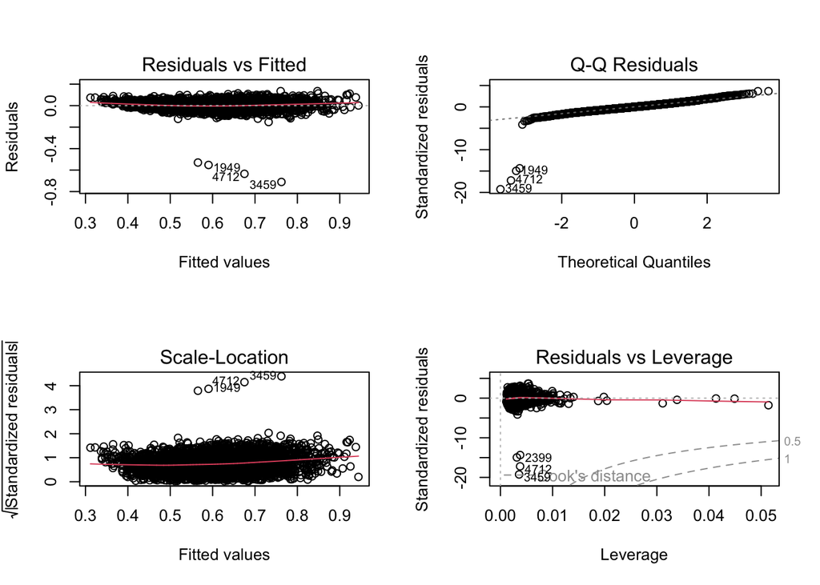

```
## Analysis of Variance Table
##
## Model 1: whr ~ waist + sex + log_bmi + age + race_eth + educ_lev + hvy.drk +
##     BMI + bp.di.m + bp.sy.m + triglcd + phy.act + income + slphr.wn
## Model 2: whr ~ sex + race_eth + age + educ_lev + hvy.drk + triglcd + bp.sy.m +
##     phy.act + log_BMI + income
##   Res.Df    RSS Df Sum of Sq     F    Pr(>F)
## 1   4365 3.5965
## 2   4369 5.9684 -4   -2.3719 719.7 < 2.2e-16 ***
## ---
## Signif. codes:  0 '***' 0.001 '**' 0.01 '*' 0.05 '.' 0.1 ' ' 1
```

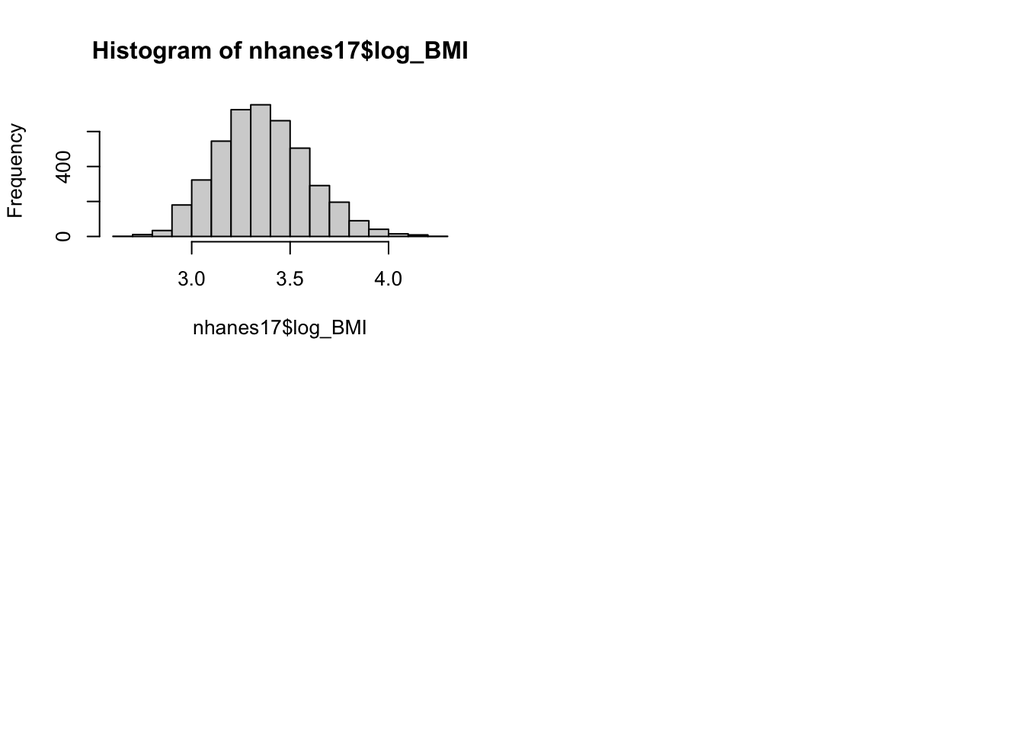